# 05 Validation: choose the best model out of sample

## Goal

Score candidate models on data they have not seen, and pick one.

## Criteria (and why)

| Metric | Meaning | Role |
| --- | --- | --- |
| **Negative log-likelihood (log score)** on test data | how much probability the model gave to what happened; penalises overconfidence | **primary** |
| Poisson deviance | generalised squared error for counts | secondary |
| MAE of annual beach totals | average miss in incidents per beach per year; easy to explain | secondary |
| Predicted / actual total | calibration: are we right in total? | check |
| Severe only: top-10 beach capture | share of actual severe incidents that fall in the 10 beaches we ranked highest (random = 12.5%) | check |
| AIC / BIC | in-sample fit, penalised for size | tie-breaker only |

**Why time-based:** the forecast is for the *future*, so we test on the future. Random splits leak (same beach, adjacent months).

**One caveat for all scores here:** the test rows use the *actual* visitors, weather and safety hours of the test year. In the real forecast (step 06) those inputs are assumed, so the real error will be larger. Step 06 checks how much larger.

```r
panel_f <- readRDS("part1/panel_f.rds")

# "Same as last year" benchmark needs each beach's count 12 months earlier
panel_f <- panel_f %>% arrange(beach_nm, month_date) %>% group_by(beach_nm) %>%
  mutate(across(c(n_all, n_mild, n_cc, n_sev), ~ lag(.x, 12), .names = "{.col}_ly")) %>%
  ungroup()
```

## 1. Single split first

Train: months before Sep 2025 (FY2017 to FY2025, 8,640 rows). Test: Sep 2025 to Aug 2026 (FY2026, 960 rows = 80 beaches x 12 months).

```r
train <- panel_f %>% filter(month_date <  as.Date("2025-09-01"))
test  <- panel_f %>% filter(month_date >= as.Date("2025-09-01"))
c(train = nrow(train), test = nrow(test))
```

```
## train  test
##  8640   960
```

```r
test %>% summarise(across(c(n_all, n_mild, n_cc, n_sev), sum))   # what actually happened
```

```
## # A tibble: 1 × 4
##   n_all n_mild  n_cc n_sev
##   <int>  <int> <int> <int>
## 1  3690   3371   293    26
```

The test year had 3,690 incidents: 3,371 mild, 293 close calls and 26 severe. The 26 severe incidents are the most in any year since FY2018, so the test year is a hard one for severe incidents.

## 2. Scoring functions

All four functions take the actual counts `y` and the predicted means `mu` for the 960 test rows.

```r
# Log score: average negative log-probability the NB gave to each observed count.
# theta = Inf is the Poisson limit (used for the benchmark, which has no dispersion).
nll_nb <- function(y, mu, theta) {
  if (is.infinite(theta)) mean(-dpois(y, mu, log = TRUE))
  else mean(-dnbinom(y, mu = mu, size = theta, log = TRUE))
}

# Poisson deviance: 2 * sum of y*log(y/mu) - (y - mu); zero when mu = y everywhere
dev_pois <- function(y, mu) 2 * sum(ifelse(y == 0, 0, y * log(y / mu)) - (y - mu))

# Add up each beach's 12 months first, then average the absolute miss over the 80 beaches
mae_beach_year <- function(y, mu, beach) mean(abs(tapply(y, beach, sum) - tapply(mu, beach, sum)))

# Rank beaches by predicted total, take the 10 highest, share of actual incidents they hold
top10_capture <- function(y, mu, beach) {
  a <- tapply(y, beach, sum); p <- tapply(mu, beach, sum)
  sum(a[order(-p)[1:10]]) / sum(a)
}

score <- function(y, mu, theta, beach) c(
  nll = nll_nb(y, mu, theta), dev = dev_pois(y, mu), mae = mae_beach_year(y, mu, beach),
  ratio = sum(mu) / sum(y), top10 = top10_capture(y, mu, beach))
```

Why the log score is the main criterion: the forecast hands Task 2 a *distribution* of incidents, not just a point. The log score is the only metric here that checks the spread as well as the centre. A model that is right on average but far too sure of itself gets punished each time an unlikely count turns up.

## 3. Compare candidate models

Each candidate adds one block of predictors to the one before, so the table shows what each block buys out of sample. Two variants test the open questions from step 04:

- `v` versions replace `offset(log(visitors))` with `log_visitors` as a normal term, so the data choose the exponent (EDA slope about 0.9).
- `M6` replaces the five fixed beach traits with one dummy per beach (`factor(beach_nm)`). It learns each beach’s own level, including anything about the beach that we have not measured. The visitor mix (`surfer_prop`, `tourist_ratio`) changes month to month, so it stays.
- `S_small` is the small severe model from step 04.

```r
time   <- c("mon", "period_2021")
cond   <- c("swell_max_m", "wind_days", "rain_mm", "air_temp_hi", "marine_health")
safety <- c("log_lg", "log_drone", "campaign_idx", "first_aid_cap", "pa_system", "flags", "equip_rating")
mix    <- c("surfer_prop", "tourist_ratio")
traits <- c("rips_per_km", "rocky", "fishing", "rockpool", "shore_len_m")

specs <- list(
  M1_visitors = list(rhs = "1"),                                   # offset + intercept only
  M2_season   = list(rhs = time),
  M3_cond     = list(rhs = c(time, cond)),
  M4_safety   = list(rhs = c(time, cond, safety)),
  M5_traits   = list(rhs = c(time, cond, safety, mix, traits)),    # = the step 04 model
  M5v_slope   = list(rhs = c(time, cond, safety, mix, traits, "log_visitors"), offset = FALSE),
  M6_beachFE  = list(rhs = c(time, cond, safety, mix, "factor(beach_nm)")),
  M6v_FEslope = list(rhs = c(time, cond, safety, mix, "factor(beach_nm)", "log_visitors"), offset = FALSE),
  S_small     = list(rhs = c("log_lg", "log_drone", "campaign_idx", "air_temp_hi", "swell_max_m", "period_2021"))
)

make_f <- function(y, s) as.formula(paste(
  y, "~", paste(s$rhs, collapse = " + "),
  if (isFALSE(s$offset)) "" else "+ offset(log(visitors))"))

# Fit every spec on `train` for response y, score on `test`, plus the "same as last year" benchmark
run_split <- function(train, test, y) {
  fits <- lapply(names(specs), function(nm) {
    m <- tryCatch(suppressWarnings(glm.nb(make_f(y, specs[[nm]]), data = train)),
                  error = function(e) NULL)
    if (is.null(m)) return(NULL)
    mu <- predict(m, test, type = "response")
    data.frame(model = nm, t(score(test[[y]], mu, m$theta, test$beach_nm)), AIC = AIC(m), BIC = BIC(m))
  })
  # benchmark: same beach, same month, last year; floored at 0.1 so a zero last year
  # does not give probability 0 to any incident this year
  ly <- pmax(test[[paste0(y, "_ly")]], 0.1)
  bench <- data.frame(model = "B0_lastyear", t(score(test[[y]], ly, Inf, test$beach_nm)), AIC = NA, BIC = NA)
  bind_rows(bench, fits)
}

sev_names <- c(n_mild = "Mild", n_cc = "Close call", n_sev = "Severe", n_all = "All")
single <- bind_rows(lapply(names(sev_names), function(y) run_split(train, test, y) %>% mutate(y = y)))
```

```r
for (y in names(sev_names)) {
  print(knitr::kable(single %>% filter(.data$y == !!y) %>% select(-y),
                     digits = 3, caption = paste("FY2026 test year:", sev_names[y])))
}
```

FY2026 test year: Mild

| model | nll | dev | mae | ratio | top10 | AIC | BIC |
| --- | --- | --- | --- | --- | --- | --- | --- |
| B0_lastyear | 2.983 | 3873.676 | 9.991 | 1.054 | 0.540 | NA | NA |
| M1_visitors | 1.812 | 2846.279 | 18.226 | 1.157 | 0.535 | 28717.15 | 28731.28 |
| M2_season | 1.786 | 2419.123 | 17.172 | 1.099 | 0.535 | 28227.92 | 28326.82 |
| M3_cond | 1.774 | 2318.227 | 16.564 | 1.070 | 0.535 | 28143.77 | 28285.05 |
| M4_safety | 1.751 | 2354.087 | 17.950 | 1.172 | 0.535 | 27865.24 | 28055.97 |
| M5_traits | 1.710 | 1966.834 | 12.598 | 1.143 | 0.535 | 27321.40 | 27561.58 |
| M5v_slope | 1.700 | 1851.956 | 11.698 | 1.082 | 0.535 | 27179.46 | 27426.70 |
| M6_beachFE | 1.670 | 1642.048 | 6.162 | 1.049 | 0.541 | 26628.44 | 27391.37 |
| M6v_FEslope | 1.670 | 1641.351 | 6.105 | 1.045 | 0.541 | 26629.70 | 27399.70 |
| S_small | 1.771 | 2520.676 | 18.899 | 1.219 | 0.535 | 27994.68 | 28051.19 |

FY2026 test year: Close call

| model | nll | dev | mae | ratio | top10 | AIC | BIC |
| --- | --- | --- | --- | --- | --- | --- | --- |
| B0_lastyear | 0.739 | 1020.314 | 2.091 | 1.128 | 0.526 | NA | NA |
| M1_visitors | 0.623 | 1073.315 | 4.065 | 1.617 | 0.464 | 10820.095 | 10834.223 |
| M2_season | 0.595 | 885.410 | 3.736 | 1.502 | 0.464 | 10410.495 | 10509.393 |
| M3_cond | 0.579 | 813.544 | 3.212 | 1.435 | 0.464 | 10230.204 | 10371.487 |
| M4_safety | 0.541 | 696.637 | 2.263 | 1.140 | 0.447 | 9813.291 | 10004.024 |
| M5_traits | 0.521 | 631.136 | 1.649 | 1.076 | 0.580 | 9607.877 | 9848.059 |
| M5v_slope | 0.518 | 620.792 | 1.609 | 1.058 | 0.580 | 9577.607 | 9824.852 |
| M6_beachFE | 0.513 | 603.189 | 1.509 | 0.981 | 0.567 | 9387.909 | 10150.838 |
| M6v_FEslope | 0.513 | 603.242 | 1.510 | 0.983 | 0.567 | 9389.894 | 10159.888 |
| S_small | 0.565 | 760.789 | 2.629 | 1.226 | 0.396 | 10059.525 | 10116.038 |

FY2026 test year: Severe

| model | nll | dev | mae | ratio | top10 | AIC | BIC |
| --- | --- | --- | --- | --- | --- | --- | --- |
| B0_lastyear | 0.173 | 281.092 | 1.117 | 4.315 | 0.385 | NA | NA |
| M1_visitors | 0.120 | 179.812 | 0.353 | 1.046 | 0.346 | 1722.583 | 1736.711 |
| M2_season | 0.113 | 166.461 | 0.355 | 1.071 | 0.346 | 1676.540 | 1775.439 |
| M3_cond | 0.114 | 167.885 | 0.328 | 1.042 | 0.385 | 1636.509 | 1777.792 |
| M4_safety | 0.113 | 166.133 | 0.308 | 0.771 | 0.423 | 1590.724 | 1781.456 |
| M5_traits | 0.109 | 157.190 | 0.256 | 0.738 | 0.462 | 1561.560 | 1801.742 |
| M5v_slope | 0.109 | 157.226 | 0.264 | 0.739 | 0.462 | 1561.818 | 1809.064 |
| M6_beachFE | 0.235 | 400.370 | 0.258 | 0.736 | 0.500 | 1626.535 | 2389.464 |
| M6v_FEslope | 0.235 | 400.246 | 0.258 | 0.742 | 0.500 | 1628.489 | 2398.483 |
| S_small | 0.113 | 165.070 | 0.325 | 0.863 | 0.385 | 1596.572 | 1653.086 |

FY2026 test year: All

| model | nll | dev | mae | ratio | top10 | AIC | BIC |
| --- | --- | --- | --- | --- | --- | --- | --- |
| B0_lastyear | 3.112 | 4020.404 | 10.002 | 1.035 | 0.543 | NA | NA |
| M1_visitors | 1.894 | 3166.263 | 21.202 | 1.214 | 0.528 | 30340.61 | 30354.74 |
| M2_season | 1.860 | 2587.998 | 19.606 | 1.143 | 0.528 | 29731.00 | 29829.90 |
| M3_cond | 1.842 | 2424.046 | 18.149 | 1.103 | 0.528 | 29591.18 | 29732.46 |
| M4_safety | 1.817 | 2496.750 | 19.979 | 1.180 | 0.528 | 29261.47 | 29452.21 |
| M5_traits | 1.770 | 2043.349 | 13.706 | 1.150 | 0.528 | 28663.60 | 28903.79 |
| M5v_slope | 1.758 | 1906.262 | 12.607 | 1.088 | 0.528 | 28515.18 | 28762.42 |
| M6_beachFE | 1.722 | 1664.226 | 6.303 | 1.040 | 0.540 | 27896.03 | 28658.96 |
| M6v_FEslope | 1.722 | 1663.680 | 6.263 | 1.037 | 0.540 | 27897.50 | 28667.49 |
| S_small | 1.842 | 2657.365 | 21.052 | 1.225 | 0.528 | 29470.19 | 29526.70 |

One test year is one draw. Before choosing, check that the winners hold up across years.

## 4. Rolling origin

Five folds: test on FY2022, FY2023, FY2024, FY2025 and FY2026, each time training on every earlier year (an expanding window). FY2021 is not used as a test year, because the `period_2021` flag would then be estimated from only one training year.

```r
roll <- bind_rows(lapply(2022:2026, function(f) bind_rows(lapply(names(sev_names), function(y)
  run_split(filter(panel_f, fy < f), filter(panel_f, fy == f), y) %>% mutate(fold = f, y = y)))))

roll_summary <- roll %>% group_by(y, model) %>%
  summarise(nll_mean = mean(nll), nll_sd = sd(nll), mae = mean(mae), ratio = mean(ratio),
            top10 = mean(top10), .groups = "drop") %>%
  group_by(y) %>% arrange(nll_mean, .by_group = TRUE) %>% ungroup()

wins <- roll %>% group_by(y, fold) %>% slice_min(nll, n = 1) %>% ungroup() %>% count(y, model, name = "folds_won")

for (y in names(sev_names)) {
  print(knitr::kable(roll_summary %>% filter(.data$y == !!y) %>% left_join(wins, by = c("y", "model")) %>%
                       mutate(folds_won = coalesce(folds_won, 0L)) %>% select(-y),
                     digits = 4, caption = paste("Rolling origin, 5 folds:", sev_names[y])))
}
```

Rolling origin, 5 folds: Mild

| model | nll_mean | nll_sd | mae | ratio | top10 | folds_won |
| --- | --- | --- | --- | --- | --- | --- |
| M6_beachFE | 1.6116 | 0.0833 | 7.0336 | 0.9986 | 0.5575 | 2 |
| M6v_FEslope | 1.6116 | 0.0833 | 7.0307 | 0.9941 | 0.5575 | 3 |
| M5v_slope | 1.6391 | 0.0929 | 10.9137 | 1.0250 | 0.5374 | 0 |
| M5_traits | 1.6489 | 0.0937 | 11.7616 | 1.0752 | 0.5374 | 0 |
| M4_safety | 1.6838 | 0.0958 | 15.6655 | 1.1027 | 0.5374 | 0 |
| S_small | 1.6920 | 0.0999 | 16.2018 | 1.1266 | 0.5374 | 0 |
| M3_cond | 1.7017 | 0.0892 | 16.2108 | 1.0830 | 0.5374 | 0 |
| M2_season | 1.7079 | 0.0961 | 16.9761 | 1.0997 | 0.5374 | 0 |
| M1_visitors | 1.7362 | 0.0962 | 17.7917 | 1.1479 | 0.5374 | 0 |
| B0_lastyear | 3.0487 | 0.2530 | 9.8218 | 0.9381 | 0.5521 | 0 |

Rolling origin, 5 folds: Close call

| model | nll_mean | nll_sd | mae | ratio | top10 | folds_won |
| --- | --- | --- | --- | --- | --- | --- |
| M5v_slope | 0.5343 | 0.0219 | 1.8214 | 1.1199 | 0.5113 | 3 |
| M5_traits | 0.5366 | 0.0239 | 1.8786 | 1.1387 | 0.4997 | 0 |
| M4_safety | 0.5491 | 0.0230 | 2.2950 | 1.2236 | 0.4458 | 0 |
| S_small | 0.5646 | 0.0258 | 2.4855 | 1.2753 | 0.4342 | 0 |
| M6_beachFE | 0.5707 | 0.0714 | 1.5498 | 1.0284 | 0.5148 | 2 |
| M6v_FEslope | 0.5710 | 0.0717 | 1.5490 | 1.0270 | 0.5148 | 0 |
| M3_cond | 0.5819 | 0.0247 | 3.0994 | 1.5403 | 0.4492 | 0 |
| M2_season | 0.5951 | 0.0234 | 3.4777 | 1.5851 | 0.4492 | 0 |
| M1_visitors | 0.6150 | 0.0284 | 3.5956 | 1.6169 | 0.4492 | 0 |
| B0_lastyear | 0.7662 | 0.0663 | 2.4992 | 1.2167 | 0.4721 | 0 |

Rolling origin, 5 folds: Severe

| model | nll_mean | nll_sd | mae | ratio | top10 | folds_won |
| --- | --- | --- | --- | --- | --- | --- |
| M5v_slope | 0.0878 | 0.0130 | 2.880000e-01 | 1.002900e+00 | 0.4512 | 2 |
| M5_traits | 0.0878 | 0.0131 | 2.846000e-01 | 1.004100e+00 | 0.4512 | 1 |
| M4_safety | 0.0891 | 0.0146 | 3.099000e-01 | 1.089500e+00 | 0.3985 | 0 |
| S_small | 0.0895 | 0.0136 | 3.372000e-01 | 1.197000e+00 | 0.3481 | 1 |
| M3_cond | 0.0922 | 0.0133 | 3.539000e-01 | 1.470500e+00 | 0.4296 | 0 |
| M2_season | 0.0933 | 0.0125 | 3.726000e-01 | 1.507400e+00 | 0.4138 | 0 |
| M1_visitors | 0.0961 | 0.0150 | 3.556000e-01 | 1.391100e+00 | 0.4138 | 1 |
| B0_lastyear | 0.1635 | 0.0062 | 1.223500e+00 | 5.666300e+00 | 0.2393 | 0 |
| M6v_FEslope | 0.3395 | 0.2501 | 8.108146e+08 | 3.529412e+09 | 0.4704 | 0 |
| M6_beachFE | 0.3445 | 0.2577 | 8.036045e+08 | 3.492719e+09 | 0.4482 | 0 |

Rolling origin, 5 folds: All

| model | nll_mean | nll_sd | mae | ratio | top10 | folds_won |
| --- | --- | --- | --- | --- | --- | --- |
| M6_beachFE | 1.6778 | 0.0768 | 7.2987 | 0.9997 | 0.5515 | 2 |
| M6v_FEslope | 1.6778 | 0.0767 | 7.2900 | 0.9955 | 0.5515 | 3 |
| M5v_slope | 1.7091 | 0.0862 | 11.8483 | 1.0401 | 0.5293 | 0 |
| M5_traits | 1.7198 | 0.0874 | 12.9071 | 1.0915 | 0.5293 | 0 |
| M4_safety | 1.7583 | 0.0889 | 17.4828 | 1.1211 | 0.5293 | 0 |
| S_small | 1.7701 | 0.0902 | 18.0570 | 1.1441 | 0.5293 | 0 |
| M3_cond | 1.7776 | 0.0769 | 17.7022 | 1.1267 | 0.5293 | 0 |
| M2_season | 1.7877 | 0.0851 | 19.0735 | 1.1539 | 0.5293 | 0 |
| M1_visitors | 1.8222 | 0.0840 | 20.2033 | 1.2084 | 0.5293 | 0 |
| B0_lastyear | 3.1951 | 0.1749 | 10.3632 | 0.9352 | 0.5468 | 0 |

`nll_sd` is mostly the difference between years (some years are easier to predict than others), so compare models within a fold, as in the plot below, rather than reading it as the error of the mean.

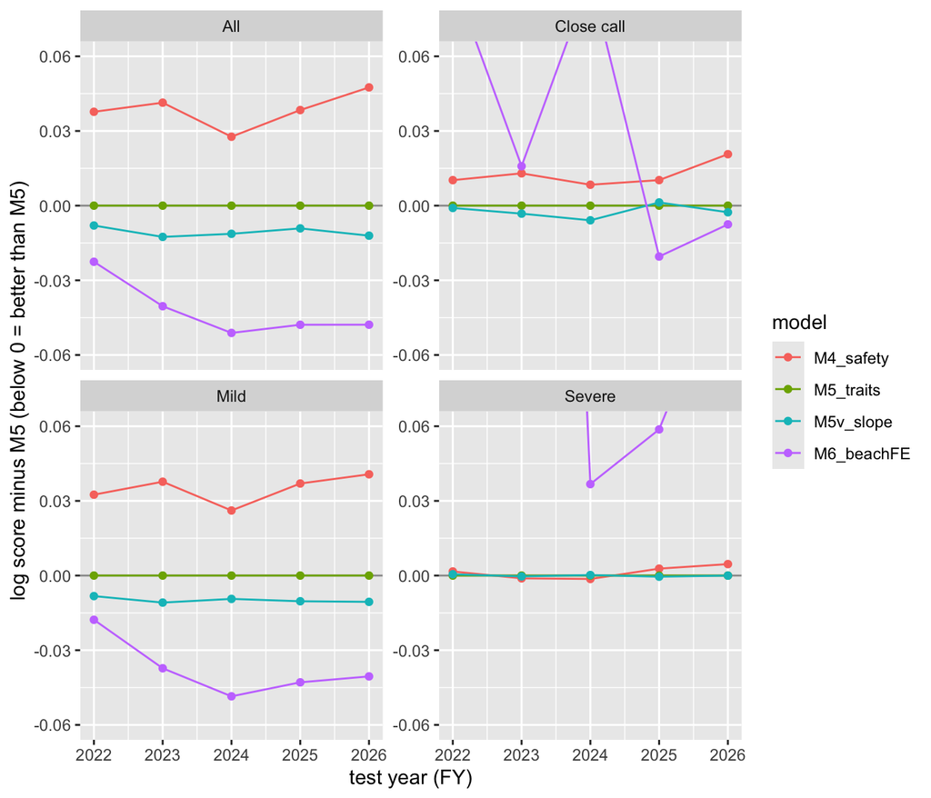

```r
# Log score in each fold, relative to the full traits model (M5), so year-to-year noise drops out
roll %>% filter(model %in% c("M4_safety", "M5_traits", "M5v_slope", "M6_beachFE")) %>%
  group_by(y, fold) %>% mutate(diff = nll - nll[model == "M5_traits"]) %>% ungroup() %>%
  mutate(y = sev_names[y]) %>%
  ggplot(aes(fold, diff, colour = model)) + geom_hline(yintercept = 0, colour = "grey60") +
  geom_line() + geom_point() + facet_wrap(~y, scales = "free_y") +
  coord_cartesian(ylim = c(-0.06, 0.06)) +
  labs(x = "test year (FY)", y = "log score minus M5 (below 0 = better than M5)")
```

The plot cuts off the severe fixed-effects line, which sits far above the others in every fold.

What the folds say:

- **Mild: a beach fixed-effects model wins every fold** (`M6` and `M6v` are tied to four decimals and split the wins; mean log score 1.61 vs 1.64 for the best model without them), with calibration close to 1.00 on average. An easy decision.
- **Close calls: the full traits model wins on average** (0.537, or 0.534 with a free visitor exponent) and fixed effects come only fifth (0.571). Fixed effects won the two most recent folds but lost the first three by more. With about 300 close calls a year spread over 80 beaches, 80 beach dummies are too many to estimate well. This agrees with the earlier analysis notes.
- **Severe: the full traits model is the best on average** (0.0878) and its total is right on average (ratio 1.00 over five years). The winner changes from fold to fold (four different models win at least one fold), which is what about 20 events a year looks like. Even the winner is only slightly better than simpler models. Fixed effects fail in every fold.
- **Free visitor exponent (`M5v`).** Tied with `M5` for severe and 0.003 better for close calls. Too small a gain to give up the simple reading of “incidents per visitor”.

## 5. Challenger: XGBoost

Does a flexible machine-learning model find something the GLMs miss? We run gradient-boosted trees (XGBoost) through the same five folds and score them against the model chosen for each severity.

**How it works here.**

1. **Start from visitors.** Each beach-month starts at log(visitors), passed as `base_margin`. This is the offset again: the trees learn incidents per visitor, not raw counts.
2. **Add small trees.** Each tree asks a few yes/no questions (e.g. “swell above 2.3 m and lifeguard hours below 400?”) and each end point (leaf) adds a number to the log rate. The prediction is visitors x exp(sum of all trees), so on the same log scale as the GLM.
3. **Each tree fixes the current errors.** With the Poisson objective a leaf’s value is roughly the log of actual / predicted for the rows it holds, shrunk towards zero when they have few incidents, then scaled by the learning rate (0.03).
4. **Interactions come free.** Trees 2 to 4 levels deep combine 2 to 4 inputs, so effects like “swell matters more at rocky beaches” are found without writing them in. The GLM only has them if we add them.
5. **Stop before overfitting.** Inside each training window the last year is held out to choose tree depth, minimum leaf size and the number of trees (early stopping), then the model is refitted on the whole window. The test year is never seen.
6. **Add a spread.** XGBoost only gives a mean. For the log score we fit a negative binomial `theta` to the held-out year’s predictions; where that estimate is unbounded we use Poisson.

Inputs are the same as the traits model, with month and marine health as numbers and lifeguard and drone hours unlogged (trees do not care about monotone transforms).

```r
library(xgboost)
set.seed(1)

xfeats <- c("mon_i", "period_2021", "swell_max_m", "wind_days", "rain_mm", "air_temp_hi", "mh_i",
            "lg_hrs", "drone_hrs", "campaign_idx", "first_aid_cap", "pa_system", "flags", "equip_rating",
            "surfer_prop", "tourist_ratio", "rips_per_km", "rocky", "fishing", "rockpool", "shore_len_m")
panel_f <- panel_f %>% mutate(mon_i = as.integer(as.character(mon)), mh_i = as.integer(marine_health))
dmat <- function(d, y) xgb.DMatrix(as.matrix(d[xfeats]), label = d[[y]], base_margin = log(d$visitors))

xgrid <- expand.grid(max_depth = c(2, 3, 4), min_child_weight = c(1, 10))

# Tune on the last training year, refit on all training years
fit_xgb <- function(train, y) {
  last <- max(train$fy)
  d_in <- dmat(filter(train, fy < last), y); val <- filter(train, fy == last); d_val <- dmat(val, y)
  res <- lapply(seq_len(nrow(xgrid)), function(i) {
    p <- list(objective = "count:poisson", eta = 0.03, max_depth = xgrid$max_depth[i],
              min_child_weight = xgrid$min_child_weight[i], subsample = 0.8, colsample_bytree = 0.8,
              eval_metric = "poisson-nloglik")
    m <- xgb.train(p, d_in, nrounds = 3000, evals = list(val = d_val), early_stopping_rounds = 100, verbose = 0)
    list(p = p, n = xgb.attr(m, "best_iteration") + 1, m = m,
         score = min(attributes(m)$evaluation_log$val_poisson_nloglik))
  })
  best  <- res[[which.min(sapply(res, `[[`, "score"))]]
  mu_v  <- predict(best$m, d_val, iterationrange = c(1, best$n))
  theta <- tryCatch(as.numeric(theta.ml(val[[y]], mu_v, limit = 100)), error = function(e) Inf)
  list(m = xgb.train(best$p, dmat(train, y), nrounds = best$n, verbose = 0), theta = theta)
}

chosen <- c(n_mild = "M6_beachFE", n_cc = "M5_traits", n_sev = "M5_traits")   # the GLMs picked in section 4
xgb_roll <- bind_rows(lapply(2022:2026, function(f) bind_rows(lapply(names(chosen), function(y) {
  train <- filter(panel_f, fy < f); test <- filter(panel_f, fy == f)
  x <- fit_xgb(train, y)
  data.frame(model = "XGB", t(score(test[[y]], predict(x$m, dmat(test, y)), x$theta, test$beach_nm)),
             fold = f, y = y)
}))))

vs <- bind_rows(roll %>% filter(model == chosen[y]) %>% mutate(model = "GLM") %>% select(names(xgb_roll)),
                xgb_roll)
xgb_wins <- vs %>% group_by(y, fold) %>% summarise(xgb_win = nll[model == "XGB"] < nll[model == "GLM"], .groups = "drop") %>%
  group_by(y) %>% summarise(xgb_folds_won = sum(xgb_win))
knitr::kable(vs %>% group_by(y = sev_names[y], model) %>%
               summarise(nll = mean(nll), mae = mean(mae), ratio = mean(ratio), top10 = mean(top10), .groups = "drop") %>%
               left_join(xgb_wins %>% mutate(y = sev_names[y]), by = "y") %>%
               mutate(xgb_folds_won = ifelse(model == "XGB", xgb_folds_won, 5L - xgb_folds_won)) %>%
               rename(folds_won = xgb_folds_won),
             digits = 4, caption = "Rolling origin, 5 folds: chosen GLM vs XGBoost")
```

Rolling origin, 5 folds: chosen GLM vs XGBoost

| y | model | nll | mae | ratio | top10 | folds_won |
| --- | --- | --- | --- | --- | --- | --- |
| Close call | GLM | 0.5366 | 1.8786 | 1.1387 | 0.4997 | 0 |
| Close call | XGB | 0.5154 | 1.5320 | 1.0776 | 0.5120 | 5 |
| Mild | GLM | 1.6116 | 7.0336 | 0.9986 | 0.5575 | 1 |
| Mild | XGB | 1.6054 | 6.9677 | 0.9925 | 0.5574 | 4 |
| Severe | GLM | 0.0878 | 0.2846 | 1.0041 | 0.4512 | 2 |
| Severe | XGB | 0.0854 | 0.2978 | 1.1247 | 0.4451 | 3 |

What it says:

- **Mild: close to a tie.** XGBoost is marginally ahead (1.605 vs 1.612, 4 folds to 1, annual miss 7.0 for both), a fifth of the gap that fixed effects opened over traits in section 4. The beach fixed effects already hold most of what the trees find.
- **Close calls: XGBoost wins every fold** (0.515 vs 0.537) and cuts the annual miss per beach by about 18% (1.53 vs 1.88). The gain is seven times the gap that separated `M5` and `M5v` in section 4, so the close-call GLM is missing real structure, most likely interactions or curved effects. It also overpredicts less (1.08 vs 1.14).
- **Severe: no clear winner.** XGBoost’s log score is slightly lower (0.0854 vs 0.0878, 3 folds of 5, which is chance with about 20 events a year), but it overpredicts the total by 12% on average while the GLM is right (1.12 vs 1.00), and its annual miss per beach is larger.
- This is not tilted towards XGBoost: the GLMs were chosen on these same five folds, XGBoost was tuned only inside each training window.

**What it does to the Task 2 lever.** Fit both severe models on all data, take FY2026’s inputs, and scale lifeguard hours at every beach-month:

```r
fy26  <- filter(panel_f, fy == 2026)
g_sev <- glm.nb(make_f("n_sev", specs$M5_traits), data = panel_f)
x_sev <- fit_xgb(panel_f, "n_sev")
lever <- t(sapply(c(0.5, 0.75, 1, 1.5, 2, 3), function(s) {
  nd <- fy26 %>% mutate(lg_hrs = lg_hrs * s, log_lg = log1p(lg_hrs))
  c(lg_hrs_x = s, GLM = sum(predict(g_sev, nd, type = "response")), XGB = sum(predict(x_sev$m, dmat(nd, "n_sev"))))
}))
knitr::kable(lever, digits = c(2, 1, 1), caption = "Expected severe incidents, FY2026 inputs, lifeguard hours scaled")
```

Expected severe incidents, FY2026 inputs, lifeguard hours scaled

| lg_hrs_x | GLM | XGB |
| --- | --- | --- |
| 0.50 | 22.0 | 25.6 |
| 0.75 | 21.1 | 23.2 |
| 1.00 | 20.5 | 21.6 |
| 1.50 | 19.6 | 20.3 |
| 2.00 | 19.1 | 19.8 |
| 3.00 | 18.3 | 19.1 |

The GLM gives one smooth effect with a standard error. XGBoost says cutting patrols hurts more (25.6 vs 22.0 at half the hours) and adding them helps about as much up to double, then flattens: a tree cannot extrapolate past the most hours a beach has had, so a large funding increase would show little extra benefit. Neither is causal (step 06, section 7).

**Verdict.** Keep the GLMs. For severe, the GLM’s total is right on average, its range can be simulated from `coef` and `vcov` (step 06), and its effects are what Task 2 needs; XGBoost’s edge is within noise. For close calls, the XGBoost win is a signal, not a replacement: the next step is to find what it picked up (e.g. SHAP interaction values) and add those terms to the close-call GLM.

## 6. Decision

**One model per severity, each a negative binomial GLM with `offset(log(visitors))`:**

| Severity | Model | Decided by | Runner-up |
| --- | --- | --- | --- |
| Mild | `M6_beachFE`: season, conditions, safety, visitor mix + **one dummy per beach** | log score; a fixed-effects model won all 5 folds | `M6v` tied (so take the simpler offset version), `M5v` 0.03 worse |
| Close call | `M5_traits`: the step 04 model (season, conditions, safety, visitor mix, beach traits) | mean log score over 5 folds | `M5v` 0.003 better, not worth the extra term, so we take the simpler offset version |
| Severe | `M5_traits` (same as close calls) | mean log score, calibration 1.00 over 5 folds | `M5v` tied; fixed effects overfit badly |

Why this split makes sense: fixed effects need data. Mild incidents happen about 3,300 times a year, enough to learn each beach’s own level. Close calls and severe incidents are too rare for that, so they borrow strength across beaches through the measured traits (rips, rocks, fishing, rockpools, length). That is also the more useful model for Task 2, since it says *why* a beach is risky.

Forecast totals for all incidents are the sum of the three severity forecasts.

What to tell the panel:

- The models were chosen on five years they had not seen, not on how well they fit the past.
- For severe incidents the model gets the total right on average, but any single year can be off by about a quarter (FY2026: 26 actual vs about 19 predicted). Report a range, not a point (step 06).
- The ranking of risky beaches is more reliable than the count: the top 10 beaches hold about 45% of severe incidents, against 12.5% at random.

```r
saveRDS(list(mild = specs$M6_beachFE, cc = specs$M5_traits, sev = specs$M5_traits), "part1/chosen_specs.rds")
```